# 17 ATTENTION MECHANISMS

## 17.1 Attention Functions

#### What is Attention?

**Attention** is, to some extent, motivated by how we pay visual attention to different regions of an image or correlate words in one sentence.

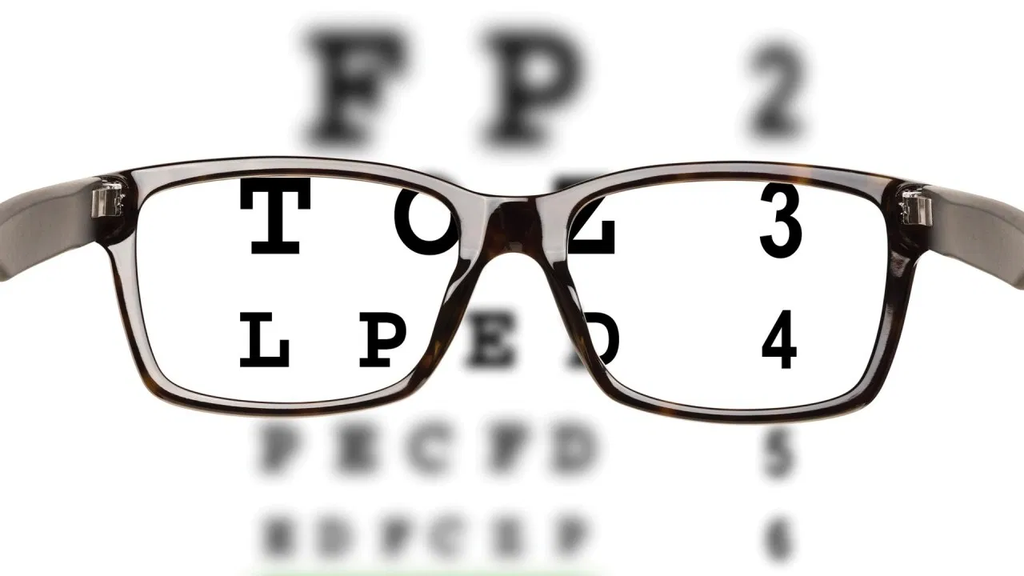

### Attention Functions

#### Attention Function

An **attention function** can be described as mapping a **query** $\boldsymbol{q}$ and a set of **key**-**value** pairs $\{(\boldsymbol{k}_{i},\boldsymbol{v}_{i})\}$ to **an output** $\boldsymbol{o}$

[figure not shown]

The output is computed as a *weighted sum* of the *values*, where the weight assigned to each value is computed by **a compatibility function** $\alpha$ of the *query* with the corresponding *key*.
$$\begin{equation}
\boldsymbol{o}=\text{Attention}(\boldsymbol{q},\boldsymbol{k}_{1...n},\boldsymbol{v}_{1...n})=\sum_{i=1}^{n}\alpha(\boldsymbol{q},\boldsymbol{k}_{i})\boldsymbol{v}_{i}
\end{equation}$$
where $\sum_{i=1}^{n}\alpha(\boldsymbol{q},\boldsymbol{k}_{i})=1$

### Type of attention

#### Type of attention

- In **global** attention, we consider all the keys.
- In **local** attention, we consider only a subset of the keys.

[figure not shown]

- In **soft** attention, the function $\alpha$ varies smoothly over its domain and, as a result, it is **differentiable**.
- In **hard** attention, the function $\alpha$ determine whether to attend to a region or not, which means that the function has many abrupt changes over its domain.

[figure not shown]

## 17.2 Attention Pooling

### NonParametric Kernel Regression

#### Kernel Regression

- **Problem**: Given a dataset of input-output pairs $\mathcal{D}=\{(\boldsymbol{x}_{1},y_{1}),\ldots,(\boldsymbol{x}_{N},y_{N})\}$, how to learn $f$ to predict the output $\hat{y}=f(\boldsymbol{x})$ for any new input $\boldsymbol{x}$?
- **Solution**: Consider $(\boldsymbol{x}_{i},y_{i})$ as a pair of key-value and $x$ as query

  | **key** | **value** |
  | --- | --- |
  | $\boldsymbol{x}_{1}$ | $y_{1}$ |
  | $\vdots$ | $\vdots$ |
  | $\boldsymbol{x}_{N}$ | $y_{N}$ |

$$\begin{equation}
\hat{y}=\sum_{i=1}^{N}\alpha(\boldsymbol{x},\boldsymbol{x}_{i})y_{i},
\end{equation}$$

- We define $\alpha$ using a Gaussian kernel
  $$\begin{equation}
  \alpha(\boldsymbol{x},\boldsymbol{x}_{i})=\frac{\exp\left[-\frac{1}{2}\left\Vert \boldsymbol{x}-\boldsymbol{x}_{i}\right\Vert ^{2}\right]}{\sum_{j=1}^{n}\exp\left[-\frac{1}{2}\left\Vert \boldsymbol{x}-\boldsymbol{x}_{j}\right\Vert ^{2}\right]}.
  \end{equation}$$
  and plug it into equation (17)

$$\begin{equation}
\begin{split}\begin{aligned}\hat{y} & =\sum_{i=1}^{N}\alpha(\boldsymbol{x},\boldsymbol{x}_{i})y_{i}\\
& =\sum_{i=1}^{N}\frac{\exp\left[-\frac{1}{2}\left\Vert \boldsymbol{x}-\boldsymbol{x}_{i}\right\Vert ^{2}\right]}{\sum_{j=1}^{N}\exp\left[-\frac{1}{2}\left\Vert \boldsymbol{x}-\boldsymbol{x}_{j}\right\Vert ^{2}\right]}y_{i}
\end{aligned}
\end{split}
\end{equation}$$

- A key $\boldsymbol{x}_{i}$ that is closer to the given query $\boldsymbol{x}$ will get more attention via a larger attention weight assigned to the key’s corresponding value $y_{i}$.

#### Example 1

- Generate an artificial dataset including 50 training examples and 50 testing examples according to the following nonlinear function with the noise term $\epsilon\sim\mathcal{N}(0,0.5)$
  $$y=2\sin(x)+x^{0.8}+\epsilon$$
- Find the kernel regression

[figure not shown]

### Parametric Kernel Regression

#### Parametric Kernel Regression

- Kernel regression enjoys the consistency benefit: given enough data this model converges to the optimal solution.
- Nonetheless, we can easily integrate learnable parameters.
- In the following the distance between the query $\boldsymbol{x}$ and the key $\boldsymbol{x}_{i}$ is multiplied a learnable parameter ${\color{red}w}$:

$$\begin{equation}
\begin{split}\begin{aligned}\hat{y} & =\sum_{i=1}^{N}\frac{\exp\left[-\frac{1}{2}\left(\left\Vert \boldsymbol{x}-\boldsymbol{x}_{i}\right\Vert {\color{red}w}\right)^{2}\right]}{\sum_{j=1}^{N}\exp\left[-\frac{1}{2}\left(\left\Vert \boldsymbol{x}-\boldsymbol{x}_{j}\right\Vert {\color{red}w}\right)^{2}\right]}y_{i}\end{aligned}
\end{split}
\end{equation}$$

#### Example 2

- Generate an artificial dataset including 50 training examples and 50 testing examples according to the following nonlinear function with the noise term $\epsilon\sim\mathcal{N}(0,0.5)$
  $$y=2\sin(x)+x^{0.8}+\epsilon$$
- Find the parametric kernel regression

[figure not shown]

## 17.3 Attention Scoring Functions

#### Introduction

- We use an **attention scoring function** and **softmax function** to compute the attention function

[figure not shown]

An **attention scoring function** is used to measure the relevance between a query and a key

[figure not shown]

Attention scores from different sources

- **English**: “The agreement on the European Economic Area was signed in August 1992”
- **French**: “L’accord sur la zone économique européenne a été signé en août 1992.”

[figure not shown]

#### Some Attention Scoring Functions

- Additive score (Bahdanau et al. 2015)
  $$\begin{equation}
  \text{score}(\boldsymbol{q},\boldsymbol{k})={\color{red}\boldsymbol{w}}_{v}^{\top}\text{tanh}({\color{red}W}_{q}\boldsymbol{q}+{\color{red}W}_{k}\boldsymbol{k})
  \end{equation}$$
- Multiplicative score (Luong et al. 2015)
  $$\begin{equation}
  \text{score}(\boldsymbol{q},\boldsymbol{k})=\boldsymbol{q}^{\top}{\color{red}W}\boldsymbol{k}
  \end{equation}$$
- Dot-product score (Luong et al. 2015)
  $$\begin{equation}
  \text{score}(\boldsymbol{q},\boldsymbol{k})=\boldsymbol{q}^{\top}\boldsymbol{k}
  \end{equation}$$
- Scaled dot-product score (Vaswani et al. 2017)
  $$\begin{equation}
  \text{score}(\boldsymbol{q},\boldsymbol{k})=\frac{\boldsymbol{q}^{\top}\boldsymbol{k}}{\sqrt{dim(\boldsymbol{k})}}
  \end{equation}$$
- Cosine score (Graves et al. 2014)

$$\begin{equation}
\text{score}(\boldsymbol{q},\boldsymbol{k})=\text{cosine}(\boldsymbol{q},\boldsymbol{k})
\end{equation}$$

#### Example 1

- Using **dot-product score** to calculate the output $\boldsymbol{o}$ given that

$$\boldsymbol{q}=\left(\begin{array}{c}
1\\
-1\\
2
\end{array}\right),\boldsymbol{k}_{1}=\left(\begin{array}{c}
2\\
1\\
-2
\end{array}\right),\boldsymbol{v}_{1}=\left(\begin{array}{c}
2\\
3
\end{array}\right),\boldsymbol{k}_{2}=\left(\begin{array}{c}
1\\
2\\
-1
\end{array}\right),\boldsymbol{v}_{2}=\left(\begin{array}{c}
1\\
2
\end{array}\right),\boldsymbol{k}_{3}=\left(\begin{array}{c}
3\\
-2\\
0
\end{array}\right),\boldsymbol{v}_{3}=\left(\begin{array}{c}
3\\
1
\end{array}\right)$$

[figure not shown]

## 17.4 Attention Layer

#### Attention Layer

**Input**:

- Query vectors: $Q$
- Memory vectors: $X$

**Output**:

- Output vectors: $Y$

**Parameter**s: ${\color{red}W_{K}},{\color{red}W_{V}}$

**Function**:

$$Y=\text{AttentionLayer}(X,Q;{\color{red}W_{K}},{\color{red}W_{V}})$$

[figure not shown]

#### Self-Attention Layer

**Input**:

- Input vectors: $X$

**Output**:

- Output vectors: $Y$

**Parameters**: ${\color{red}W_{K}},{\color{red}W_{V}},{\color{red}W_{Q}}$

**Function**:

$$Y=\text{SelfAttentionLayer}(X;{\color{red}W_{K}},{\color{red}W_{V}},{\color{red}W_{Q}})$$

[figure not shown]

#### Example 2

- Calculate the output of the self-attention layer given that
  $$X=\left(\begin{array}{ccc}
  \boldsymbol{x}_{1} & \boldsymbol{x}_{2} & \boldsymbol{x}_{3}\end{array}\right)=\left(\begin{array}{ccc}
  1 & 0 & 1\\
  0 & 2 & 1\\
  1 & 0 & 1\\
  0 & 2 & 1
  \end{array}\right)$$

$${\color{red}W_{K}}=\left(\begin{array}{cccc}
0 & 1 & 0 & 1\\
0 & 1 & 1 & 1\\
1 & 0 & 0 & 0
\end{array}\right),{\color{red}W_{Q}}=\left(\begin{array}{cccc}
1 & 1 & 0 & 0\\
0 & 0 & 0 & 1\\
1 & 0 & 1 & 1
\end{array}\right),{\color{red}W_{V}}=\left(\begin{array}{cccc}
0 & 0 & 1 & 1\\
2 & 3 & 0 & 1
\end{array}\right)$$

#### Positional Encoding

- Unlike RNNs that recurrently process tokens of a sequence one by one, self-attention ditches sequential operations in favor of parallel computation.
- To use the sequence order information, we can inject absolute or relative positional information by adding positional encoding to the input representations.
- Positional encodings can be either learned or fixed.
- Suppose that the input representation $X\in\mathbb{R}^{n\times d}$ contains the $d$-dimensional embeddings for $n$ tokens of a sequence. The positional encoding outputs $X+P$ using a positional embedding matrix $P\in\mathbb{R}^{n\times d}$ of the same shape, whose element on the $i^{\mathrm{th}}$ row and the $(2j)^{\mathrm{th}}$ or the $(2j+1)^{\mathrm{th}}$ column
  $$\begin{align}
  \begin{split}\begin{aligned}p_{i,2j} & =\sin\left(\frac{i}{10000^{2j/d}}\right),\\
  p_{i,2j+1} & =\cos\left(\frac{i}{10000^{2j/d}}\right).
  \end{aligned}
  \end{split}
  \end{align}$$

#### Multi-Head Attention

- In practice, it may be beneficial to use different representation subspaces of queries, keys, and values.

[figure not shown]

**Input**:

- Query vectors: $Q$
- Key vectors: $K$
- Value vectors: $V$

**Output**:

$$\begin{equation}
\begin{aligned}\text{MultiHeadAttention}(Q,K,V) & =[\text{head}_{1};\dots;\text{head}_{h}]{\color{red}W^{O}}\\
\text{where head}_{i} & =\text{Attention}(Q{\color{red}W_{i}^{Q}},K{\color{red}W_{i}^{K}},V{\color{red}W_{i}^{V}}),i=1...h
\end{aligned}
\end{equation}$$
where ${\color{red}W_{i}^{Q}},{\color{red}W_{i}^{K}},{\color{red}W_{i}^{V}}$, and ${\color{red}W^{O}}$ are parameter matrices to be learned.

- Multi-head self-attention for the sentence “the girl loved me.” with 12 heads

[figure not shown]

## 17.5 Applications

### Vision

#### CNN with Self-Attention

[figure not shown]

#### Image Captioning with RNNs and Attention

[figure not shown]

- Attention over time. As the model generates each word, its attention changes to reflect the relevant parts of the image. “soft” (top row) vs “hard” (bottom row) attention.

[figure not shown]

### Transformer

#### The Transformer

**Transformers** are a new neural network model that only uses attention!

**Transformer Block**

- **Input**: Set of vectors $\boldsymbol{x}$
- **Output**: Set of vectors $\boldsymbol{y}$
- Self-attention is the only interaction between vectors!
- Layer norm and MLP work independently per vector
- Highly scalable, highly parallelizable

[figure not shown]

A Transformer is a sequence of transformer blocks

[figure not shown]

#### Transfer Learning

> “ImageNet Moment for (Natural) Language Processing”

**Pretraining**:

- Download a lot of text from the internet
- Train a giant Transformer model for language modeling

**Finetuning**:

- Fine-tune the Transformer on your own language task

[figure not shown]

#### Scaling up Transformers

| **Model** | **Layers** | **Width** | **Heads** | **Params** | **Data** | **Training** |
| --- | --- | --- | --- | --- | --- | --- |
| Transformer-Base | 12 | 512 | 8 | 65M |  | 8x P100 (12 hours) |
| Transformer-Large | 12 | 1024 | 16 | 213M |  | 8x P100 (3.5 days) |
| BERT-Base | 12 | 768 | 12 | 110M | 13GB |  |
| BERT-Large | 24 | 1024 | 16 | 340M | 13GB |  |
| XLNet-Large | 24 | 1024 | 16 | ~340M | 126GB | 512x TPU-v3 (2.5 days) |
| RoBERTa | 24 | 1024 | 16 | 355M | 160GB | 1024x V100 GPU (1 day) |
| GPT-2 | 48 | 1600 | ? | 1.5B | 40GB |  |
| Megatron-LM | 72 | 3072 | 32 | 8.3B | 174GB | 512x V100 GPU (9 days) |
| Turing-NLG | 78 | 4256 | 28 | 17B | ? | 256x V100 GPU |
| GPT-3 | 96 | 12288 | 96 | 175B | 694GB | ? |

## 17.6 References

[video not shown]